# Sustainable Digitalization - A primer

DSI PhD Excellence Program Course 2023 - Day 2

Mario Angst

# Day 2 Program

## Day 2 - Learning goals

- The participants are aware of existing frameworks to relate digitalization to sustainability transformations.
- The participants are aware of current research on (non-)alignment of digitalization with regard to sustainability goals.
- The participants can relate their own research to questions of sustainable digitalization.
- The lecturer does support creative group work

## Day 2 - Program

- Day 1 recap: Share your readings
- Input: Sustainable digitalization
- Reflection: Sustainability in my own research
- Build your own susdigi research project

## Your readings

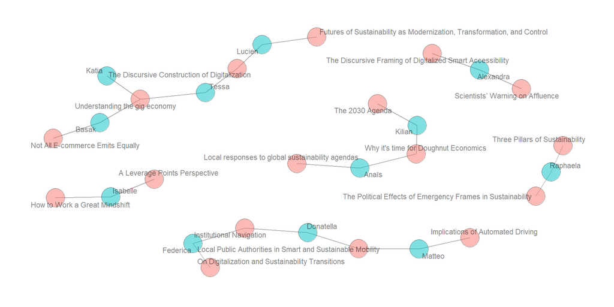

## (slightly very random) clusters

Pre-assigned groups:

- Policy wonks: Federica, Donatella, Matteo
- Deep thinkers: Isabelle, Lucien, Raphaela
- Post-growthers: Kilian, Anais, Alexandra
- Smart economyists: Basak, Katia, Tessa

## Share your readings

In the groups:

- Sit down silently for 5 minutes.
- Write down three sentences summarizing the articles you read.
- Read them to each other.
- Discuss: Which conceptual elements we discussed on day 1 did you encounter?

# Day 1 leftovers

## Digitalization and its discoursive construction

Defining Digitalization

For our purposes: Socio-technical consequences of digitization, the conversion of analogue streams of information into digital form.

Argument for the time being: What and how to digitize always involves decisions - as well as regulation and non-regulation of its socio-technical consequences.

## The UN 2030 Agenda

- Outcome of a political process
- Anyone remember the Millenium Development Goals? The Agenda 21?
- Conceptually weak, normatively… powerful? Evidence is mixed.

# Sustainable digitalization

## Starting point: The LES framework

- Hilty and Aebischer (2015)
- Originally conceived to look at “impacts of ICT infrastructure” on sustainability
- focus on resource use impacts
- Advantages:
  - relatively empirical (eg. no a priori stance on substitution)
  - conceptually elegant in focus on resource theory
  - but expandable (as we do here to digitalization more generally)

## The LES framework

- *L*ife cycle impacts
- *E*nabling impacts
- *S*tructural impacts

## Life cycle impacts

Actual material impacts

- Production and disposal
- Operating the infrastructure

Data center example: Energy, land…

## Enabling impact

- New actions that are enabled by digitalization (or prevented)

Three types of enabling impacts regarding resources:

- Process optimization: Immaterial replaces material resource (information reducing travel impacts)
- Media substitution: material replaces material resource (e-book, physical books)
- Externalization of control: immaterial replaces immaterial (eg. centralizing a previous process optimization step)

## Structural impact

Persistent macro-level changes in:

- economic structure
- societal institutions

## LES x core strategies bingo

Categorizing research and interventions for sustainable digitalization

|  | Life-cycle | Enabling | Structural |
| --- | --- | --- | --- |
| Sufficiency |  |  |  |
| Efficiency |  |  |  |
| Consistency |  |  |  |

## Sustainable digitalization imaginaries

- Remember?
  - Modernization: weak sustainability, green growth
  - Transformation: strong sustainability, solidarity economy, post-growth
  - Control: emergency, inevitability, powerful entities “solve”

## Exercise

We will form three groups (one per imaginary).

We will go outside.

Imagine your idealtypical scenario has played out.

How has this place changed? What role did digitalization play for these changes to take place?

## Non-alignment - a few examples

- Life cycle impacts: Massive absolute growth dwarfs consistent efficiency gains in IcT infrastructure and devices
- Enabling: Efficiency gains have been underwhelming (transportation, IoT, logistics..)
- Structural:
  - Digital economy - extractive business model with large social costs, monopolized infrastructure
  - Unhinged narrative power of big tech

# Sustainable Digitalization in my own research

# Build your own susdigi research project

Form teams with:

- A policy wonk
- A deep thinker
- A post-growthist
- A smart economyist

# Build your own susdigi research project

Take 30 minutes. Develop an *empirical* research project skeleton with:

- A research question
- A way to answer the research question. Sketch:
  - What data would you use?
  - What methods to analyze the data would you use?

[figure not shown]

Sustainable Digitalization - A primer